# Raissa’s reference document

## Introduction

My neighbour’s name is Anna. She chose:

- Mauritius
- Canada
1. Mauritius
2. Canada

[output not shown]

A table with pander

| country | continent | year | lifeExp | pop | gdpPercap |
| --- | --- | --- | --- | --- | --- |
| Canada | Americas | 1952 | 68.75 | 14785584 | 11367 |
| Canada | Americas | 1957 | 69.96 | 17010154 | 12490 |
| Canada | Americas | 1962 | 71.3 | 18985849 | 13462 |
| Canada | Americas | 1967 | 72.13 | 20819767 | 16077 |
| Canada | Americas | 1972 | 72.88 | 22284500 | 18971 |
| Canada | Americas | 1977 | 74.21 | 23796400 | 22091 |
| Canada | Americas | 1982 | 75.76 | 25201900 | 22899 |
| Canada | Americas | 1987 | 76.86 | 26549700 | 26627 |
| Canada | Americas | 1992 | 77.95 | 28523502 | 26343 |
| Canada | Americas | 1997 | 78.61 | 30305843 | 28955 |
| Canada | Americas | 2002 | 79.77 | 31902268 | 33329 |
| Canada | Americas | 2007 | 80.65 | 33390141 | 36319 |
| Poland | Europe | 1952 | 61.31 | 25730551 | 4029 |
| Poland | Europe | 1957 | 65.77 | 28235346 | 4734 |
| Poland | Europe | 1962 | 67.64 | 30329617 | 5339 |
| Poland | Europe | 1967 | 69.61 | 31785378 | 6557 |
| Poland | Europe | 1972 | 70.85 | 33039545 | 8007 |
| Poland | Europe | 1977 | 70.67 | 34621254 | 9508 |
| Poland | Europe | 1982 | 71.32 | 36227381 | 8452 |
| Poland | Europe | 1987 | 70.98 | 37740710 | 9082 |
| Poland | Europe | 1992 | 70.99 | 38370697 | 7739 |
| Poland | Europe | 1997 | 72.75 | 38654957 | 10160 |
| Poland | Europe | 2002 | 74.67 | 38625976 | 12002 |
| Poland | Europe | 2007 | 75.56 | 38518241 | 15390 |

## Tip from Raissa

```r
library(huxtable)
library(flextable)
dfHt <- huxtable(df,add_colnames = TRUE)

condition <- which(dfHt$year>1990)
dfHt <- dfHt %>%  set_text_color(condition, everywhere,'blue')

dfHt <- dfHt %>% set_all_borders(everywhere,everywhere,1) %>% set_all_border_colors(everywhere,everywhere,'green')

output_format <- knitr::opts_knit$get("rmarkdown.pandoc.to")
  if(('word_document' %in% output_format)|('docx' %in% output_format)){
huxtable::as_flextable(dfHt) } else {
  dfHt
}
```

| country | continent | year | lifeExp | pop | gdpPercap |
| --- | --- | --- | --- | --- | --- |
| Canada | Americas | 1952 | 68.8 | 14785584 | 1.14e+04 |
| Canada | Americas | 1957 | 70 | 17010154 | 1.25e+04 |
| Canada | Americas | 1962 | 71.3 | 18985849 | 1.35e+04 |
| Canada | Americas | 1967 | 72.1 | 20819767 | 1.61e+04 |
| Canada | Americas | 1972 | 72.9 | 22284500 | 1.9e+04 |
| Canada | Americas | 1977 | 74.2 | 23796400 | 2.21e+04 |
| Canada | Americas | 1982 | 75.8 | 25201900 | 2.29e+04 |
| Canada | Americas | 1987 | 76.9 | 26549700 | 2.66e+04 |
| Canada | Americas | 1992 | 78 | 28523502 | 2.63e+04 |
| Canada | Americas | 1997 | 78.6 | 30305843 | 2.9e+04 |
| Canada | Americas | 2002 | 79.8 | 31902268 | 3.33e+04 |
| Canada | Americas | 2007 | 80.7 | 33390141 | 3.63e+04 |
| Poland | Europe | 1952 | 61.3 | 25730551 | 4.03e+03 |
| Poland | Europe | 1957 | 65.8 | 28235346 | 4.73e+03 |
| Poland | Europe | 1962 | 67.6 | 30329617 | 5.34e+03 |
| Poland | Europe | 1967 | 69.6 | 31785378 | 6.56e+03 |
| Poland | Europe | 1972 | 70.8 | 33039545 | 8.01e+03 |
| Poland | Europe | 1977 | 70.7 | 34621254 | 9.51e+03 |
| Poland | Europe | 1982 | 71.3 | 36227381 | 8.45e+03 |
| Poland | Europe | 1987 | 71 | 37740710 | 9.08e+03 |
| Poland | Europe | 1992 | 71 | 38370697 | 7.74e+03 |
| Poland | Europe | 1997 | 72.8 | 38654957 | 1.02e+04 |
| Poland | Europe | 2002 | 74.7 | 38625976 | 1.2e+04 |
| Poland | Europe | 2007 | 75.6 | 38518241 | 1.54e+04 |

## Plots

We are now going to create a plot for our two countries

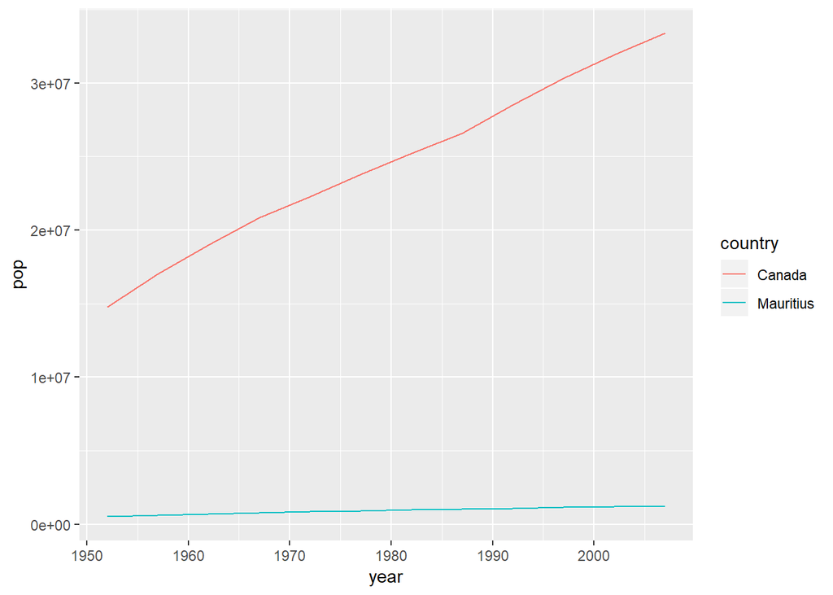

Population of my two countries

## Using in-line code and parameter

Remember how we include parameters in our YAML header. I can now ask RMarkdown to include those names here. RMarkdown will print the first parameter if I put the inline code as follows:

- Mauritius
- Canada

## Using loops

[1] “Mauritius” [1] “Canada”

You can put some text here before the tables

[output not shown]

Table-Canada

| year | country | pop |
| --- | --- | --- |
| 1952 | Canada | 14785584 |
| 1957 | Canada | 17010154 |
| 1962 | Canada | 18985849 |
| 1967 | Canada | 20819767 |
| 1972 | Canada | 22284500 |
| 1977 | Canada | 23796400 |
| 1982 | Canada | 25201900 |
| 1987 | Canada | 26549700 |
| 1992 | Canada | 28523502 |
| 1997 | Canada | 30305843 |
| 2002 | Canada | 31902268 |
| 2007 | Canada | 33390141 |

## Citing documents

To have a bibliography, you can use a .bib file (you can export those from a number of reference managers such as JabRef and Mendeley). Here I have created a bibliography which includes the knitr package and the huxtable package. I can refer to them using the labels for them.

For example: The knitr package (Xie 2018) is the basis of R markdown.

## Bibliography

Xie, Yihui. 2018. *Knitr: A General-Purpose Package for Dynamic Report Generation in R*. https://CRAN.R-project.org/package=knitr.